# **Predicting energy consumption at an hourly frequency for San Diego Gas & Electric (SDGE) utility region**

## Table of contents:

## 1. Introduction

## 2. Data

### $\quad$ 2.1. Energy consumption data

#### $\quad$ $\quad$ 2.1.1 Importing energy data

#### $\quad$ $\quad$ 2.1.2 Cleaning energy data

#### $\quad$ $\quad$ 2.1.3 Adding features to energy data

### $\quad$ 2.2. Weather data

#### $\quad$ $\quad$ 2.2.1 Importing weather data

#### $\quad$ $\quad$ 2.2.2 Cleaning weather data

#### $\quad$ $\quad$ 2.2.3 Merging weather data to energy data

### $\quad$ 2.3. Solar/PV installation data

#### $\quad$ $\quad$ 2.3.1 Importing PV data

#### $\quad$ $\quad$ 2.3.2 Cleaning PV data

#### $\quad$ $\quad$ 2.3.3 Merging PV data to energy and weather data

## 3. Data wrangling, Exploration, Stats

### $\quad$ 3.1. Exploring energy data by itself

### $\quad$ 3.2. Exploring energy and weather data together

### $\quad$ 3.3. Exploring energy and PV installations data together

## 4. Future work

# 1. Introduction

Electrical utilities need to diligently plan ahead of time the allocation of generating units in their power plants to match their regional energy demand (MW), because if the demand is higher than the generation it can cause several blackouts resulting in a huge loss to the economy; on the other hand if the generation is higher than the demand the extra electricity will be wasted and it can also create an unnecessary load on the transmission lines.

So, it is very important for the utilities to have a forecast of the energy consumption to be able to allocate appropriate resources to meet their demand. A year, month or day ahead forecast can help the utilities plan for a larger time scale but for smoother daily operations an hourly (or even better) forecast can prove very useful. For example, if the plant operators get a high energy forecast for the next hour, they can ramp up the energy supply by switching on more power plants.

This project will involve analyzing past 5 years of hourly energy consumption data of SDGE utility to find trends in energy consumption around hour of the day, day of the week, season of the year, etc. and also to check if factors like outside temperature and solar installations in the region affect the energy consumption. That is, a model can be built to predict the energy consumption given parameters like day of the week, time of the day, season, holiday, local weather, renewable capacity added in the local market, etc.

The developed prediction model can be utilized by the electrical utilities to effectively plan their energy generation operations and balance the demand with appropriate supply. An efficient forecast can prove very useful for the utilities in planning their day to day operations, meeting their customers’ energy demand, and avoiding excess generation of energy.

```python
# importing all the required libraries and modules
import pandas as pd
import numpy as np
import matplotlib.pyplot as plt
import seaborn as sns
import requests
import json
from bs4 import BeautifulSoup
from lxml import html
from datetime import datetime, timedelta
from pandas.tseries.holiday import USFederalHolidayCalendar as calendar
import scipy.stats
import matplotlib.dates as mdates
plt.style.use('bmh')
```

# 2. Data

## 2.1. Energy consumption data

### 2.1.1 Importing energy data

The hourly energy consumption data for the 4 utilities- PGE (Pacific Gas and Electric), SCE (Southern California Edison), SDGE (San Diego Gas and Electric) and VEA (Valley Electric Association, which actually covers some parts of Nevada)- under the CAISO (California Independent System Operator) is available on CAISO’s website in the form of .csv files. The most recent data for past 3 months and 2018 is available on http://www.caiso.com/planning/Pages/ReliabilityRequirements/Default.aspx and previous data upto 2014 is available in the arhive folder here: http://www.caiso.com/Pages/documentsbygroup.aspx?GroupID=8879C382-6EA8-4357-B752-D4F571388958.

Python’s requests and html packages were used to extract the .csv files directly from the websites and stored in dictionaries before concatenating them into a single dataframe.

Below is the map of CA and surrounding states showing the regional divisions in the CAISO- regions served by the utilities PGE, SCE, SDGE and VEA can be clearly seen here.

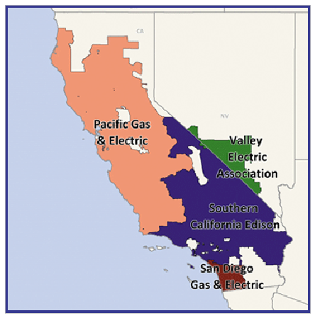

```python
# https://www.ferc.gov/market-oversight/mkt-electric/california.asp
ca_map = plt.imread('ca_elect_map.jpg')
_ = plt.figure(figsize = (8,8))
_ = plt.imshow(ca_map)
_ = plt.xticks([])
_ = plt.yticks([])
```

```python
#Storing the data URLs; the first URL has the most recent data (2018-2019) and the archive URL has old data (2014-2017)
url = "http://www.caiso.com/planning/Pages/ReliabilityRequirements/Default.aspx"
#url_archive="http://www.caiso.com/planning/Pages/ReliabilityRequirements/ReliabilityRequirementsArchive.aspx"
url_archive = "http://www.caiso.com/Pages/documentsbygroup.aspx?GroupID=8879C382-6EA8-4357-B752-D4F571388958"
```

```python
#Requesting the data and getting a response from both the URls
r = requests.get(url)
r_archive = requests.get(url_archive)
```

```python
#getting the html content
tree = html.fromstring(r.content)
tree_archive = html.fromstring(r_archive.content)
```

```python
#Using xpath and web scrapping to get the exact location of the data files on the website by using inspect method on the websites
file = tree.xpath('//*[@id="NodeTempate"]/a[@class="ISOTreeNodeTxt"]//@href')
file_archive = tree_archive.xpath('//*[@id="NodeTempate"]/a[@class="ISOTreeNodeTxt"]//@href')
```

```python
#Checking if files were imported correctly; the hourly data is stored in all files starting with "Historical..."
hourly_data=[]
for doc in file:
    if "Historical" in doc:
        print(doc)
        hourly_data.append(doc)
```

```
/Documents/HistoricalEMSHourlyLoadforMay2019.xlsx
/Documents/HistoricalEMSHourlyLoadforApril2019.xlsx
/Documents/HistoricalEMSHourlyLoadforMarch2019.xlsx
/Documents/HistoricalEMSHourlyLoadforFebruary2019.xlsx
/Documents/HistoricalEMSHourlyLoadforJanuary2019.xlsx
/Documents/HistoricalEMSHourlyLoad-2018.xlsx
```

```python
#Doing the same for archive files
hourly_data_arch=[]
for doc1 in file_archive:
    if "Historical" in doc1:
        print(doc1)
        hourly_data_arch.append(doc1)
```

```
/Documents/HistoricalEMSHourlyLoad-2014.xlsx
/Documents/HistoricalEMSHourlyLoad-2015.xlsx
/Documents/HistoricalEMSHourlyLoad-2016.xlsx
/Documents/HistoricalEMSHourlyLoad-2017.xlsx
```

```python
#reading in all the archive excel files into a dict: hourly_arch_dict with key names with respective years in it
hourly_arch_dict={}
for doc1 in file_archive:
    if "Historical" in doc1:
        hourly_arch_dict['hourly_load'+'_'+doc1.strip('.xlsx')[-4:]]=pd.read_excel('http://www.caiso.com'+doc1)
```

```python
#adding in only the 2018 data from 'hourly_data' into the dict: hourly_arch_dict; considering only full years for now.
# Later this code block can be changed to take in the rest of the months of 2019 as well
hourly_arch_dict['hourly_load_2018'] = pd.read_excel('http://www.caiso.com'+hourly_data[-1])
```

```python
#Checking the dict if the keys were named correctly
hourly_arch_dict.keys()
```

```
dict_keys(['hourly_load_2014', 'hourly_load_2015', 'hourly_load_2016', 'hourly_load_2017', 'hourly_load_2018'])
```

```python
#Checking the head of the data for each year
#for keys, items in hourly_arch_dict.items():
#    print("\nhead of "+keys+"\n")
#    print(items.head())
```

### 2.1.2 Cleaning energy data

```python
#Checking the tail of the data for each year
for keys, items in hourly_arch_dict.items():
    print("\ntail of "+keys+"\n")
    print(items.tail()[3:])
```

```
tail of hourly_load_2014

                   Dates       Date  HE    PGE    SCE  SDGE  VEA  CAISO Total
8758 2014-12-31 22:00:00 2014-12-31  23  11319  11541  2594   90        25544
8759 2014-12-31 23:00:00 2014-12-31  24  10824  11081  2436   88        24429

tail of hourly_load_2015

                   Dates       Date  HE    PGE    SCE  SDGE  VEA  CAISO Total
8758 2015-12-31 22:00:00 2015-12-31  23  11184  11131  2448   96        24859
8759 2015-12-31 23:00:00 2015-12-31  24  10885  10751  2302   97        24035

tail of hourly_load_2016

                   Dates       Date  HE    PGE    SCE  SDGE  VEA  CAISO Total
8782 2016-12-31 22:00:00 2016-12-31  23  11147  10667  2270   67        24152
8783 2016-12-31 23:00:00 2016-12-31  24  10872  10249  2144   66        23332

tail of hourly_load_2017

                       Dates       Date                      HE      PGE  \
8758 2017-12-31 22:59:59.990 2017-12-31 2017-12-31 22:59:59.990  10499.5
8759 2017-12-31 23:59:59.990 2017-12-31 2017-12-31 23:59:59.990  10023.1

          SCE     SDGE      VEA CAISO Total
8758  10421.1  2259.74  70.1344     23250.4
8759  9957.15  2123.18  71.2226     22174.6

tail of hourly_load_2018

                       Dates       Date  HE           PGE           SCE  \
8758 2017-12-31 22:59:59.990 2017-12-31  23  10499.475128  10421.094713
8759 2017-12-31 23:59:59.990 2017-12-31   0  10023.052203   9957.145479

             SDGE        VEA   CAISO Total
8758  2259.741640  70.134432  23250.445733
8759  2123.183153  71.222568  22174.603618
```

- The Dates column is the datetime column and the columns PGE, SCE, SDGE, VEA represent the energy consumption in the respective utility regions in MWH ($10^6$ Wh). And the 'CAISO Total' column gives the sum of the energy consumption of these 4 utiltiy regions.
- It can be seen that the format of Dates column of 2017 and 2018 is a bit different than the other years' Dates column.
- Also, the last few entries in the Dates column of the year 2018 have 2017 as the year instead of 2018.
- Checking the number of rows in each year; ideally they should be 8760 for each year except 2016 because it was a leap year so the number of rows in 2014, 2015, 2017 and 2018 should be 8760 each and that in 2016 should be 8784.

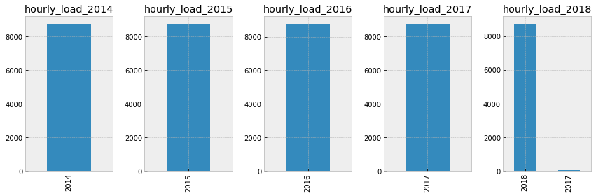

```python
#for keys, items in hourly_arch_dict.items():
#    print("\n"+keys+"\n")
#    print(items.groupby(items['Dates'].dt.year).count())
plt.figure(figsize = (12,4))
for i, (keys, items) in enumerate(hourly_arch_dict.items()):
    ax = plt.subplot(151+i)
    items['Dates'].dt.year.value_counts().plot(kind='bar', subplots = True, ax = ax)
    ax.set_title("{}".format(keys))
plt.tight_layout()
```

- It looks like the data in 2018 has some 24 rows labeled as 2017. The plausible explanation to this is that somewhere in the data, 24 hours of year 2018 (after looking at the tail we can see that these are the last 24 hours of the year, 31st Dec) weren't recorded and the data from 2017 was used to fill in the missing values. This left the Dates column with the 2017 instead of 2018. Let's replace any 2017 value in the 'Dates' column of the 2018 data with 2018.

```python
hourly_arch_dict['hourly_load_2018']['Dates'] = hourly_arch_dict['hourly_load_2018']['Dates']. \
            mask(hourly_arch_dict['hourly_load_2018']['Dates'].dt.year!=2018, \
            hourly_arch_dict['hourly_load_2018']['Dates'] + pd.offsets.DateOffset(year=2018))
# could have used 'list(hourly_arch_dict.keys())[4][-4:]' instead of 2018 to avoid hardcoding and can apply this as a
#general check on all the dataframes when importing the data itself
```

```python
#Checking if the 2018 data has all 2018s now
hourly_arch_dict['hourly_load_2018'].groupby(hourly_arch_dict['hourly_load_2018']['Dates'].dt.year).count()
```

| Dates | Dates | Date | HE | PGE | SCE | SDGE | VEA | CAISO Total |
| --- | --- | --- | --- | --- | --- | --- | --- | --- |
| 2018 | 8760 | 8760 | 8760 | 8760 | 8760 | 8760 | 8760 | 8760 |

- Let's concatenate the data into a single dataframe before starting the cleaning process

```python
hourly1418 = pd.concat(hourly_arch_dict, axis='rows', ignore_index=True)
```

```python
hourly1418.head()
```

|  | Dates | Date | HE | PGE | SCE | SDGE | VEA | CAISO Total |
| --- | --- | --- | --- | --- | --- | --- | --- | --- |
| 0 | 2014-01-01 00:00:00 | 2014-01-01 | 1 | 10057 | 9862 | 2096 | 58 | 22073 |
| 1 | 2014-01-01 01:00:00 | 2014-01-01 | 2 | 9707 | 9530 | 1986 | 59 | 21283 |
| 2 | 2014-01-01 02:00:00 | 2014-01-01 | 3 | 9438 | 9200 | 1936 | 61 | 20635 |
| 3 | 2014-01-01 03:00:00 | 2014-01-01 | 4 | 9309 | 9015 | 1896 | 64 | 20283 |
| 4 | 2014-01-01 04:00:00 | 2014-01-01 | 5 | 9319 | 8987 | 1899 | 67 | 20271 |

- The 'Dates' column is already in datetime format, so we can directly use Datetime operations on the column.
- But the other values, except HE, are energy consumption values which should be in float or int format. We'll need to convert these columns to numeric datatype.
- Also, converting all the rows in 'Dates' column data which are in the format'201x-xx-xx yy:59:59.992' to '201x-xx-xx yy:00:00' by using dt.floor; this will make the Datetime rows in 'Dates' column uniform

```python
hourly1418['Dates']=hourly1418['Dates'].dt.floor('H')
```

```python
#Checking the number of rows in each year again;
hourly1418.groupby(hourly1418['Dates'].dt.year).count()
```

| Dates | Dates | Date | HE | PGE | SCE | SDGE | VEA | CAISO Total |
| --- | --- | --- | --- | --- | --- | --- | --- | --- |
| 2014 | 8760 | 8760 | 8760 | 8760 | 8760 | 8760 | 8760 | 8760 |
| 2015 | 8760 | 8760 | 8760 | 8760 | 8760 | 8760 | 8760 | 8760 |
| 2016 | 8784 | 8784 | 8784 | 8784 | 8784 | 8784 | 8784 | 8784 |
| 2017 | 8760 | 8760 | 8760 | 8760 | 8760 | 8760 | 8760 | 8760 |
| 2018 | 8760 | 8760 | 8760 | 8760 | 8760 | 8760 | 8760 | 8760 |

- Converting the energy consumption values to numeric; while converting to numeric, it was observed that some of the values in the columns were strings, so passing the errors='coerce' argument to the pd.to_numeric method. Also, after the conversion checking for any null values.

```python
for col in hourly1418.columns[3:]:
    hourly1418[col]=pd.to_numeric(hourly1418[col], errors='coerce')
```

```python
# Checking for missing values in each column
hourly1418.isnull().sum()
```

```
Dates          0
Date           0
HE             0
PGE            3
SCE            3
SDGE           3
VEA            3
CAISO Total    3
dtype: int64
```

- We can see that the dataframe has 3 missing values only, so by using *errors = 'coerce'* we didn't lose much of our data, which justifies the use of 'coerce' method here.
- Since the number of missing values is less, checking precisely where the null values are in the dataframe.

```python
hourly1418[hourly1418.isna().any(axis=1)]
```

|  | Dates | Date | HE | PGE | SCE | SDGE | VEA | CAISO Total |
| --- | --- | --- | --- | --- | --- | --- | --- | --- |
| 27986 | 2017-03-12 02:00:00 | 2017-03-12 | 2017-03-12 02:59:59.992000 | NaN | NaN | NaN | NaN | NaN |
| 27987 | 2017-03-12 03:00:00 | 2017-03-12 | 2017-03-12 03:59:59.992000 | NaN | NaN | NaN | NaN | NaN |
| 33697 | 2017-11-05 01:00:00 | 2017-11-05 | 2017-11-05 01:59:59.991000 | NaN | NaN | NaN | NaN | NaN |

- We only have 3 missing values and we can choose how to fill them. Since this is an energy consumption data, we need to keep in mind that the energy consumption of a region (including cities and rural) changes depending on the hour of the day, day of the week, month of the year, season and the year itself. So, we can fill the missing values with the average values of the matching month and weekday for the same hours from the rest of the data for that year.

```python
#Filling in the missing values by the average values from the same hour, weekday and month taken from rest of the data from that
# year
for date in hourly1418[hourly1418.isna().any(axis=1)].Dates:
    hourly1418[hourly1418.Dates == date] = hourly1418[hourly1418.Dates == date].fillna\
                                                   (hourly1418[(hourly1418.Dates.dt.year == date.year) &\
                                                               (hourly1418.Dates.dt.month == date.month) & \
                                                               (hourly1418.Dates.dt.weekday == date.dayofweek) &\
                                                               (hourly1418.Dates.dt.hour == date.hour) \
                                                               ].mean())
```

- Checking for missing values again; we can see that the missing values have been filled successfully

```python
print(hourly1418[hourly1418.isna().any(axis=1)])
print(hourly1418.isnull().sum())
```

```
Empty DataFrame
Columns: [Dates, Date, HE, PGE, SCE, SDGE, VEA, CAISO Total]
Index: []
Dates          0
Date           0
HE             0
PGE            0
SCE            0
SDGE           0
VEA            0
CAISO Total    0
dtype: int64
```

- Plotting the data to check if all the data cleaning opeations were successful and there are no outliers

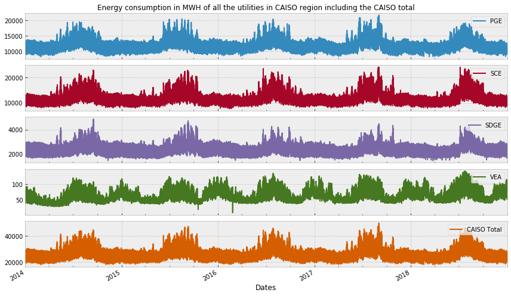

```python
hourly1418.set_index('Dates')[['PGE', 'SCE', 'SDGE', 'VEA', 'CAISO Total']].plot(subplots = True, figsize = (12,7))
[ax.legend(loc = 1) for ax in plt.gcf().axes]
plt.suptitle('Energy consumption in MWH of all the utilities in CAISO region including the CAISO total')
plt.tight_layout()
plt.subplots_adjust(top = 0.95)
```

- Checking the descriptive stats of the data

```python
hourly1418.info()
```

```
<class 'pandas.core.frame.DataFrame'>
RangeIndex: 43824 entries, 0 to 43823
Data columns (total 8 columns):
Dates          43824 non-null datetime64[ns]
Date           43824 non-null datetime64[ns]
HE             43824 non-null object
PGE            43824 non-null float64
SCE            43824 non-null float64
SDGE           43824 non-null float64
VEA            43824 non-null float64
CAISO Total    43824 non-null float64
dtypes: datetime64[ns](2), float64(5), object(1)
memory usage: 2.7+ MB
```

```python
hourly1418.describe().T
```

|  | count | mean | std | min | 25% | 50% | 75% | max |
| --- | --- | --- | --- | --- | --- | --- | --- | --- |
| PGE | 43824.0 | 11930.023813 | 1989.280309 | 8245.000000 | 10499.000000 | 11671.000000 | 12818.00 | 21713.782826 |
| SCE | 43824.0 | 11963.360511 | 2600.340532 | 7666.000000 | 10082.960259 | 11477.421358 | 12930.00 | 24185.752289 |
| SDGE | 43824.0 | 2364.924334 | 481.072736 | 1437.081129 | 1995.046696 | 2298.000000 | 2622.00 | 4867.000000 |
| VEA | 43824.0 | 62.649526 | 19.277706 | 8.000000 | 49.000000 | 57.000000 | 73.00 | 141.513457 |
| CAISO Total | 43824.0 | 26320.960905 | 4950.271576 | 18030.000000 | 22664.074061 | 25591.000000 | 28445.25 | 49900.026436 |

- Writing the data to a csv file named hourly1418CA.csv

```python
hourly1418.to_csv('hourly1418CA.csv')
```

### 2.1.3. Adding features to energy data

- Focusing only on one utility for now-SDGE (San Diego Gas & Electric); selecting smaller region will make it easier in the future to import the weather data and use it as a forecasting parameter.
- Reading in the hourly energy consumption .csv file

```python
hSDGE1418 = pd.read_csv('hourly1418CA.csv',usecols=['Dates','SDGE'], parse_dates=['Dates'])
```

Checking the data

```python
hSDGE1418.head()
```

|  | Dates | SDGE |
| --- | --- | --- |
| 0 | 2014-01-01 00:00:00 | 2096.0 |
| 1 | 2014-01-01 01:00:00 | 1986.0 |
| 2 | 2014-01-01 02:00:00 | 1936.0 |
| 3 | 2014-01-01 03:00:00 | 1896.0 |
| 4 | 2014-01-01 04:00:00 | 1899.0 |

```python
hSDGE1418.info()
```

```
<class 'pandas.core.frame.DataFrame'>
RangeIndex: 43824 entries, 0 to 43823
Data columns (total 2 columns):
Dates    43824 non-null datetime64[ns]
SDGE     43824 non-null float64
dtypes: datetime64[ns](1), float64(1)
memory usage: 684.8 KB
```

```python
hSDGE1418.describe().T
```

|  | count | mean | std | min | 25% | 50% | 75% | max |
| --- | --- | --- | --- | --- | --- | --- | --- | --- |
| SDGE | 43824.0 | 2364.924334 | 481.072736 | 1437.081129 | 1995.046696 | 2298.0 | 2622.0 | 4867.0 |

- Adding weekdays, month, day of the month, hour of the day, year, season as extra columns.
- Mapping the weekdays to a dict to use the actual weekdays in words like 'Monday', etc. Python usually indicates Monday as 0, Tuesday as 1 and so on.
- Adding season based on the data on SDGE's site -> https://www.sdge.com/whenmatters#how-it-works; months from June to October are denoted as 'summer' and months from November to May as 'winter'.
- Adding holidays column to indicate whether a day was a holiday as per the US calendar or not.

```python
def season_calc(month):
    """adding season based on the data on SDGE's site -> https://www.sdge.com/whenmatters#how-it-works;
       months from June to October are denoted as 'summer' and months from November to May as 'winter'. """
    if month in [6,7,8,9,10]:
        return "summer"
    else:
        return "winter"
```

```python
weekdays = {0:'Monday', 1:'Tuesday', 2:'Wednesday', 3: 'Thursday', 4: 'Friday', 5:'Saturday', 6:'Sunday'}
hSDGE1418['Date'] = pd.to_datetime(hSDGE1418.Dates.dt.date)
hSDGE1418['year'] = hSDGE1418.Dates.dt.year
hSDGE1418['month'] = hSDGE1418.Dates.dt.month
hSDGE1418['day'] = hSDGE1418.Dates.dt.day
hSDGE1418['hour'] = hSDGE1418.Dates.dt.hour
hSDGE1418['weekday'] = hSDGE1418.Dates.dt.weekday.map(weekdays)
hSDGE1418['season'] = hSDGE1418.Dates.dt.month.apply(season_calc)
```

```python
#Adding holidays column to indicate whether a day was a holiday as per the US calendar or not
cal = calendar()
holidays = cal.holidays(start = hSDGE1418['Date'].min(), end = hSDGE1418['Date'].max())
hSDGE1418['holiday'] = hSDGE1418['Date'].isin(holidays)
```

```python
#converting the holiday column to 1 and 0, 1 indicating a holiday and 0 not a holiday; using dictionary and map to achieve this
mapped = {True:1, False:0}
hSDGE1418.holiday = hSDGE1418.holiday.map(mapped)
hSDGE1418.head()
```

|  | Dates | SDGE | Date | year | month | day | hour | weekday | season | holiday |
| --- | --- | --- | --- | --- | --- | --- | --- | --- | --- | --- |
| 0 | 2014-01-01 00:00:00 | 2096.0 | 2014-01-01 | 2014 | 1 | 1 | 0 | Wednesday | winter | 1 |
| 1 | 2014-01-01 01:00:00 | 1986.0 | 2014-01-01 | 2014 | 1 | 1 | 1 | Wednesday | winter | 1 |
| 2 | 2014-01-01 02:00:00 | 1936.0 | 2014-01-01 | 2014 | 1 | 1 | 2 | Wednesday | winter | 1 |
| 3 | 2014-01-01 03:00:00 | 1896.0 | 2014-01-01 | 2014 | 1 | 1 | 3 | Wednesday | winter | 1 |
| 4 | 2014-01-01 04:00:00 | 1899.0 | 2014-01-01 | 2014 | 1 | 1 | 4 | Wednesday | winter | 1 |

```python
#adding in another column which indicates 'non-working' days which include weekends and holidays
hSDGE1418['non_working'] = hSDGE1418.apply(lambda x: 'non-working' if \
                                         ((x['holiday'] == 1) or (x['weekday'] in ['Saturday', 'Sunday']))
                                         else 'working', axis = 1)
```

```python
hSDGE1418.head()
```

|  | Dates | SDGE | Date | year | month | day | hour | weekday | season | holiday | non_working |
| --- | --- | --- | --- | --- | --- | --- | --- | --- | --- | --- | --- |
| 0 | 2014-01-01 00:00:00 | 2096.0 | 2014-01-01 | 2014 | 1 | 1 | 0 | Wednesday | winter | 1 | non-working |
| 1 | 2014-01-01 01:00:00 | 1986.0 | 2014-01-01 | 2014 | 1 | 1 | 1 | Wednesday | winter | 1 | non-working |
| 2 | 2014-01-01 02:00:00 | 1936.0 | 2014-01-01 | 2014 | 1 | 1 | 2 | Wednesday | winter | 1 | non-working |
| 3 | 2014-01-01 03:00:00 | 1896.0 | 2014-01-01 | 2014 | 1 | 1 | 3 | Wednesday | winter | 1 | non-working |
| 4 | 2014-01-01 04:00:00 | 1899.0 | 2014-01-01 | 2014 | 1 | 1 | 4 | Wednesday | winter | 1 | non-working |

Writing the above dataframe hSDGE1418 to 'hourly1418SDGE.csv'

```python
hSDGE1418.to_csv('hourly1418SDGE.csv')
```

```python
hSDGE1418.info()
```

```
<class 'pandas.core.frame.DataFrame'>
RangeIndex: 43824 entries, 0 to 43823
Data columns (total 11 columns):
Dates          43824 non-null datetime64[ns]
SDGE           43824 non-null float64
Date           43824 non-null datetime64[ns]
year           43824 non-null int64
month          43824 non-null int64
day            43824 non-null int64
hour           43824 non-null int64
weekday        43824 non-null object
season         43824 non-null object
holiday        43824 non-null int64
non_working    43824 non-null object
dtypes: datetime64[ns](2), float64(1), int64(5), object(3)
memory usage: 3.7+ MB
```

- Converting the season, weekday and non_working columns to categorical columns

```python
hSDGE1418['season'] = hSDGE1418['season'].astype('category', ordered = True, categories = ['summer', 'winter'])
hSDGE1418['weekday'] = hSDGE1418['weekday'].astype('category', ordered = True, categories = ['Monday', 'Tuesday', 'Wednesday',\
                                                                                            'Thursday', 'Friday', \
                                                                                            'Saturday', 'Sunday'])
hSDGE1418['non_working'] = hSDGE1418['non_working'].astype('category', ordered = True, categories = ['working', 'non-working'])
```

## 2.2 Weather data

To see the impact of weather (specifically the temperature) on the energy consumption, we'll import the hourly temperature data from https://www.ncei.noaa.gov/metadata/geoportal/rest/metadata/item/gov.noaa.ncdc:C00684/html

### 2.2.1 Importing weather data

```python
# Bringing in weather data from https://www.ncei.noaa.gov/metadata/geoportal/rest/metadata/item/gov.noaa.ncdc:C00684/html
weatherdf_all = pd.read_csv('houry_data_NOAA_2014_2018.csv')
```

```python
# weatherdf.columns.values

# Keeping only the relevant columns
weatherdf = weatherdf_all[['STATION', 'DATE', 'DailyCoolingDegreeDays','DailyHeatingDegreeDays', 'HourlyDryBulbTemperature']]
```

- There are two or more weather stations in San Diego at which the weather data has been recorded. Since weather data at airports is more accurate and not biased by nearby buildings and industries we'll use the San Diego International airport data for this project.
- The 'STATION' column represents the weather station id at which the data was recorded.
- 'DATE' column gives the date and time of recording.
- 'HourlyDryBulbTemperature' is the outside temperature in $^oF$.
- Degree days are defined as the number of degrees by which the average daily temperature is higher than 65°F ('DailyCoolingDegreeDays') or lower than 65°F ('DailyHeatingDegreeDays'). Degree days reflect changes in climate and are used as a proxy for the energy demand for heating or cooling buildings.
- Initially we'll focus on using only the temperature data but cleaning other columns nonetheless for future purposes.

```python
# San Diego international airport station is represented by the 72290023188 station id

weatherdf_air = weatherdf[weatherdf.STATION == 72290023188]
weatherdf_air['DATE'] = pd.to_datetime(weatherdf_air['DATE'])
weatherdf_air.head()
```

|  | STATION | DATE | DailyCoolingDegreeDays | DailyHeatingDegreeDays | HourlyDryBulbTemperature |
| --- | --- | --- | --- | --- | --- |
| 0 | 72290023188 | 2014-01-01 00:07:00 | NaN | NaN | 52 |
| 1 | 72290023188 | 2014-01-01 00:14:00 | NaN | NaN | 52 |
| 2 | 72290023188 | 2014-01-01 00:22:00 | NaN | NaN | 52 |
| 3 | 72290023188 | 2014-01-01 00:32:00 | NaN | NaN | 52 |
| 4 | 72290023188 | 2014-01-01 00:42:00 | NaN | NaN | 50 |

```python
weatherdf_air.info()
```

```
<class 'pandas.core.frame.DataFrame'>
Int64Index: 61956 entries, 0 to 61955
Data columns (total 5 columns):
STATION                     61956 non-null int64
DATE                        61956 non-null datetime64[ns]
DailyCoolingDegreeDays      1826 non-null object
DailyHeatingDegreeDays      1826 non-null object
HourlyDryBulbTemperature    60060 non-null object
dtypes: datetime64[ns](1), int64(1), object(3)
memory usage: 2.8+ MB
```

### 2.2.2 Cleaning weather data

- The daily cooling and heating degree days are recorded at 23:59:00 of every day, so for analytical purposes we can backfill the missing values (note: if these values are to be used, an appropriate groupby or resample method should be used, as they represent daily values, not hourly).
- The weather station reports the daily cooling and heating degree days at 23:59:00 of each day, but for the same time it renders the dry bulb temperature as NaN. Since it's night time (not a peak time for energy consumption) and only one hour is missing we can use forward fill to take the previous hour's temperature.

```python
weatherdf_air[['DailyCoolingDegreeDays','DailyHeatingDegreeDays']] = \
                weatherdf_air[['DailyCoolingDegreeDays','DailyHeatingDegreeDays']].fillna(method='bfill')

weatherdf_air = weatherdf_air.fillna(method='ffill')
```

```python
# Checking for null values
weatherdf_air[weatherdf_air.isna().any(axis=1)].sum()
```

```
STATION                     0.0
DATE                        0.0
DailyCoolingDegreeDays      0.0
DailyHeatingDegreeDays      0.0
HourlyDryBulbTemperature    0.0
dtype: float64
```

```python
# Converting the degree days and temperature columns to numeric and using errors='coerce', to force convert any string
# to numeric value. This (error='coerce') method was used only after confirming that very few values were of string type
# so we don't lose any valuable data by using the 'coerce' method.
weatherdf_air['DailyCoolingDegreeDays'] = pd.to_numeric(weatherdf_air['DailyCoolingDegreeDays'], errors='coerce')
weatherdf_air['DailyHeatingDegreeDays'] = pd.to_numeric(weatherdf_air['DailyHeatingDegreeDays'], errors='coerce')
weatherdf_air['HourlyDryBulbTemperature'] = pd.to_numeric(weatherdf_air['HourlyDryBulbTemperature'], errors='coerce')
```

### 2.2.3 Merging weather data to energy data

```python
hourly_weather = weatherdf_air.set_index('DATE').resample('H').mean()
hourly_weather.head()
```

| DATE | STATION | DailyCoolingDegreeDays | DailyHeatingDegreeDays | HourlyDryBulbTemperature |
| --- | --- | --- | --- | --- |
| 2014-01-01 00:00:00 | 72290023188 | 0.0 | 7.0 | 51.0 |
| 2014-01-01 01:00:00 | 72290023188 | 0.0 | 7.0 | 51.5 |
| 2014-01-01 02:00:00 | 72290023188 | 0.0 | 7.0 | 51.8 |
| 2014-01-01 03:00:00 | 72290023188 | 0.0 | 7.0 | 50.0 |
| 2014-01-01 04:00:00 | 72290023188 | 0.0 | 7.0 | 48.8 |

```python
# Checking for null values
hourly_weather[hourly_weather.isna().any(axis=1)].sum()
```

```
STATION                     0.0
DailyCoolingDegreeDays      0.0
DailyHeatingDegreeDays      0.0
HourlyDryBulbTemperature    0.0
dtype: float64
```

```python
# resetting the index of the hourly_weather file to merge with the energy data
hourly_weather = hourly_weather.reset_index()
```

Creating a new dataframe 'wehSDGE1418' by merging the energy dataframe- 'hSDGE1418' and the 'hourly_weather' dataframes. Merging on the Dates column of the both the dataframes and using the method 'outer' to check if any of the two dataframes has values which are missing in the other dataframe.

```python
wehSDGE1418 = pd.merge(hSDGE1418, hourly_weather, how = 'outer', left_on = 'Dates', right_on= 'DATE')
```

```python
# Checking for any null values
wehSDGE1418[wehSDGE1418.isna().any(axis = 1)].sum()
```

```
Dates                       0.0
SDGE                        0.0
Date                        0.0
year                        0.0
month                       0.0
day                         0.0
hour                        0.0
weekday                     0.0
season                      0.0
holiday                     0.0
non_working                 0.0
DATE                        0.0
STATION                     0.0
DailyCoolingDegreeDays      0.0
DailyHeatingDegreeDays      0.0
HourlyDryBulbTemperature    0.0
dtype: float64
```

Since no null values were found, all the rows from hSDGE1418 were matched with the hourly_weather rows on their respective date columns.

## 2.3 Solar/PV installation data

After some initial data visualizations on the energy data it was observed that the energy consumption and peak demand (the highest demand for 1 hour interval over the entire period) have decreased over the years from 2014 to 2018. Now, this can be due to sricter energy efficiency measures being mandated, or increase of incentives for different categories of ratepayers (residential, commercial, agriculture, etc.) to install self-generation resources like solar, wind, etc. and/or energy storage in their premises to avoid peak loads and decrease overall energy consumption.

It was observed that the energy consumption decrease over the years was more dominant over the daylight hours, so we can test the theory that maybe solar capacity installed in the utility region has increased over the years and thus more and more customers are using less energy when the sun is out causing a total reduction in energy consumption. We can test this theory by importing the solar installations data in SDGE territory.

### 2.3.1 Importing PV data

The solar installations data was imported from https://www.californiadgstats.ca.gov/downloads/ -> 'NEM Currently Interconnected Data Set'. This dataset contains a lots of parameters but we will focus on the 'approval date' which represents the date when the system was conneceted to the grid and 'System Size AC' which represents the total kW power in AC of the solar panels installed at a site. To get more details about the data, one can check the 'NEM_CurrentlyInterconnectedDataKey.b29667e204f3.xlsx' workbook in the repo.

```python
# importing solar installations data from https://www.californiadgstats.ca.gov/downloads/NEM Currently Interconnected Data Set
nemsolar = pd.read_csv('NEM_CurrentlyInterconnectedDataset_2019-03-31.csv', usecols = ['Application Id',\
                      'Matched CSI Application Number',  'Application Status', \
                      'Utility', 'Service City', 'Service Zip', 'Service County', 'System Size AC', \
                      'App Approved Date',  'Electric Vehicle', 'Electric Vehicle Count'] )
nemsolar.head()
```

|  | Application Id | Matched CSI Application Number | Application Status | Utility | Service City | Service Zip | Service County | System Size AC | App Approved Date | Electric Vehicle | Electric Vehicle Count |
| --- | --- | --- | --- | --- | --- | --- | --- | --- | --- | --- | --- |
| 0 | PGE-INT-106960619 | PGE-CSI-05317 | Interconnected | PGE | SAN FRANCISCO | 94107.0 | SAN FRANCISCO | 2.510 | 2013-09-10 | NaN | 0.0 |
| 1 | PGE-INT-106960688 | PGE-CSI-22814 | Interconnected | PGE | UNION CITY | 94587.0 | ALAMEDA | 127.747 | 2011-07-13 | NaN | 0.0 |
| 2 | PGE-INT-106960698 | NaN | Interconnected | PGE | SAN FRANCISCO | 94127.0 | SAN FRANCISCO | 5.677 | 2013-10-01 | NaN | 0.0 |
| 3 | PGE-INT-111910270 | NaN | Interconnected | PGE | Woodland | 95776.0 | Yolo | 2268.457 | 2018-11-29 | No | 0.0 |
| 4 | PGE-INT-111911601 | NaN | Interconnected | PGE | SHAFTER | 93263.0 | KERN | 1871.477 | 2018-09-19 | No | 0.0 |

```python
# We are dealing with the energy data of SDGE only, so extract SDGE's data
nemsolarSDGE = nemsolar[nemsolar['Utility']== 'SDGE']
```

```python
# Checking the data
nemsolarSDGE.info()
```

```
<class 'pandas.core.frame.DataFrame'>
Int64Index: 149779 entries, 715617 to 865395
Data columns (total 11 columns):
Application Id                    149779 non-null object
Matched CSI Application Number    16902 non-null object
Application Status                149779 non-null object
Utility                           149779 non-null object
Service City                      149779 non-null object
Service Zip                       149779 non-null float64
Service County                    149779 non-null object
System Size AC                    149779 non-null float64
App Approved Date                 149779 non-null object
Electric Vehicle                  128608 non-null object
Electric Vehicle Count            98110 non-null float64
dtypes: float64(3), object(8)
memory usage: 13.7+ MB
```

### 2.3.2 Cleaning PV data

- It's good to have the above data if in future we decide to use the county or zipcode information but for now, let's focus on the approved date, i.e. the date the system was allowed by SDGE to start operation), and 'System Size AC', i.e. the installed system capacity of the solar panels in kW.

```python
# Creating a new dataframe SDGEPV which will have the dates on which the PV panels were installed and also the system AC
# capacity that was installed at sites in SDGE territory
SDGEPV = nemsolarSDGE[['App Approved Date','System Size AC']].rename(\
                                                                     {'App Approved Date': 'date_approved',\
                                                                      'System Size AC':'AC_kW' }, axis='columns'\
                                                                     ).reset_index()
SDGEPV['date_approved'] = pd.to_datetime(SDGEPV['date_approved'])
```

```python
# Sorting the rows with the date_approved column in ascending order; and deleting unwanted columns
SDGEPV = SDGEPV.set_index('date_approved').sort_index()
del SDGEPV['index']
```

```python
SDGEPV.head()
```

| date_approved | AC_kW |
| --- | --- |
| 1999-01-20 | 2.5 |
| 1999-03-30 | 2.0 |
| 1999-08-06 | 4.0 |
| 1999-08-30 | 1.5 |
| 1999-08-31 | 4.0 |

```python
# Since multiple PV systems can be installed in one day, using groupby to sum the system size installed for each day and
# storing in a new dataframe SDGEPVM
SDGEPV = SDGEPV.reset_index()
SDGEPVM = SDGEPV.groupby('date_approved').sum()
SDGEPVM.head()
```

| date_approved | AC_kW |
| --- | --- |
| 1999-01-20 | 2.5 |
| 1999-03-30 | 2.0 |
| 1999-08-06 | 4.0 |
| 1999-08-30 | 1.5 |
| 1999-08-31 | 4.0 |

- For our modeling purpose we are not interested in how much PV capacity was intalled in one day but rather we are interested in knowing how much total capacity of PV system is currently under operation in the region. So, using a cumulative of the system size we want to see how the total solar capacity in the region increased overall.

```python
SDGEPVM['cum_AC_kW'] = SDGEPVM['AC_kW'].cumsum()
```

```python
SDGEPVT = SDGEPVM.loc[wehSDGE1418.Date.min():wehSDGE1418.Date.max(), ['AC_kW','cum_AC_kW']].reset_index()
```

### 2.3.3 Merging PV data to energy and weather data

Creating a dataframe df by merging the wehSDGE1418 and SDGEPVT datasets using merge on the wehSDGE1418 dataframe because we don't want to disturb the indices of our original energy dataset.

```python
df = pd.merge(wehSDGE1418, SDGEPVT, left_on = 'Date', right_on = 'date_approved', how = 'left')
```

```python
# dropping duplicate date columns
df.drop(['DATE', 'date_approved'], axis=1, inplace=True)
```

- Checking the merged dataframe which now should include the energy, weather and PV installations data

```python
df.head()
```

|  | Dates | SDGE | Date | year | month | day | hour | weekday | season | holiday | non_working | STATION | DailyCoolingDegreeDays | DailyHeatingDegreeDays | HourlyDryBulbTemperature | AC_kW | cum_AC_kW |
| --- | --- | --- | --- | --- | --- | --- | --- | --- | --- | --- | --- | --- | --- | --- | --- | --- | --- |
| 0 | 2014-01-01 00:00:00 | 2096.0 | 2014-01-01 | 2014 | 1 | 1 | 0 | Wednesday | winter | 1 | non-working | 72290023188 | 0.0 | 7.0 | 51.0 | NaN | NaN |
| 1 | 2014-01-01 01:00:00 | 1986.0 | 2014-01-01 | 2014 | 1 | 1 | 1 | Wednesday | winter | 1 | non-working | 72290023188 | 0.0 | 7.0 | 51.5 | NaN | NaN |
| 2 | 2014-01-01 02:00:00 | 1936.0 | 2014-01-01 | 2014 | 1 | 1 | 2 | Wednesday | winter | 1 | non-working | 72290023188 | 0.0 | 7.0 | 51.8 | NaN | NaN |
| 3 | 2014-01-01 03:00:00 | 1896.0 | 2014-01-01 | 2014 | 1 | 1 | 3 | Wednesday | winter | 1 | non-working | 72290023188 | 0.0 | 7.0 | 50.0 | NaN | NaN |
| 4 | 2014-01-01 04:00:00 | 1899.0 | 2014-01-01 | 2014 | 1 | 1 | 4 | Wednesday | winter | 1 | non-working | 72290023188 | 0.0 | 7.0 | 48.8 | NaN | NaN |

```python
# Checking for null values
df.isna().sum()
```

```
Dates                           0
SDGE                            0
Date                            0
year                            0
month                           0
day                             0
hour                            0
weekday                         0
season                          0
holiday                         0
non_working                     0
STATION                         0
DailyCoolingDegreeDays          0
DailyHeatingDegreeDays          0
HourlyDryBulbTemperature        0
AC_kW                       12264
cum_AC_kW                   12264
dtype: int64
```

- Since, not necessarily every single day in 5 years (2014-18) solar panels were installed, the SDGEPVT dataframe didn't have all the rows matchhing the energy dataframe wehSDGE1418 which resulted in missing values in the AC_kW and cum_AC_kW columns.
- We can just put a 0 in place of NaN to indicate 0 installations for that day for 'AC_kW' column.
- And since the cumulative installed solar system size should remain same until the next non-NaN value is encountered, using forward fill method to fill the 'cum_AC_kW' column

```python
df['cum_AC_kW'] = df['cum_AC_kW'].fillna(method='ffill')
```

- Forward fill worked on all the rows except the first few rows because the data for SDGEPVT didn't start at 2014-01-01 00:00:00 as our energy and weather data, so we'll have to use a different method to fill in the first few missing values. So, basically the intial missing values should be equal to the first non-NaN ('cum_AC_kW' - 'AC_kW').

```python
# For the above to work, the first non-NaN indices of both the cum_AC_kW and AC_kW should be same
assert df.cum_AC_kW.first_valid_index() == df.AC_kW.first_valid_index()
```

```python
# Filling in the initial NaN values with the difference between cum_AC_kW and AC_kW
df['cum_AC_kW'] = df['cum_AC_kW'].fillna(df.iloc[df.cum_AC_kW.first_valid_index()]['cum_AC_kW']\
                                       - df.iloc[df.AC_kW.first_valid_index()]['AC_kW'])
```

```python
# And filling the NaN AC_kW values with 0 which indicates no installations
df['AC_kW'] = df['AC_kW'].fillna(0)
```

```python
# Checking for null values again
df.isna().all().all()
```

```
False
```

```python
# Creating a new dataframe SDGE_t_pv from df by setting the index on 'Dates'
```

```python
SDGE_t_pv = df.set_index('Dates')
```

```python
SDGE_t_pv.head()
```

| Dates | SDGE | Date | year | month | day | hour | weekday | season | holiday | non_working | STATION | DailyCoolingDegreeDays | DailyHeatingDegreeDays | HourlyDryBulbTemperature | AC_kW | cum_AC_kW |
| --- | --- | --- | --- | --- | --- | --- | --- | --- | --- | --- | --- | --- | --- | --- | --- | --- |
| 2014-01-01 00:00:00 | 2096.0 | 2014-01-01 | 2014 | 1 | 1 | 0 | Wednesday | winter | 1 | non-working | 72290023188 | 0.0 | 7.0 | 51.0 | 0.0 | 220992.227 |
| 2014-01-01 01:00:00 | 1986.0 | 2014-01-01 | 2014 | 1 | 1 | 1 | Wednesday | winter | 1 | non-working | 72290023188 | 0.0 | 7.0 | 51.5 | 0.0 | 220992.227 |
| 2014-01-01 02:00:00 | 1936.0 | 2014-01-01 | 2014 | 1 | 1 | 2 | Wednesday | winter | 1 | non-working | 72290023188 | 0.0 | 7.0 | 51.8 | 0.0 | 220992.227 |
| 2014-01-01 03:00:00 | 1896.0 | 2014-01-01 | 2014 | 1 | 1 | 3 | Wednesday | winter | 1 | non-working | 72290023188 | 0.0 | 7.0 | 50.0 | 0.0 | 220992.227 |
| 2014-01-01 04:00:00 | 1899.0 | 2014-01-01 | 2014 | 1 | 1 | 4 | Wednesday | winter | 1 | non-working | 72290023188 | 0.0 | 7.0 | 48.8 | 0.0 | 220992.227 |

# 3. Data wrangling, Exploration and Stats

#### Plotting some graphs to get insights from the data. Some of the questions that can be answered are:

- Checking how the energy consumption varies across any particular day averaged over the entire period. Typical average daily load profile would be a curve peaking at the evening time because most people return home from work during evening and turn on their lights, TV, AC, etc..
- Plotting monthly average load profiles. San Diego has hot summers but the winters are not that cold so we can expect the load to be higher in summers because of the cooling load on the commercial and residential buildings.
- Checking if the average monthly consumption values have increased over the years.
- Checking how the energy consumption varies for weekdays vs the weekends or the holidays
- Checking hourly vs weekday energy consumption map to get an overall idea of the consumption pattern during a typical week.
- What is the effect of weather on the energy consumption?
- Has the increasing number of solar installations behind the customer meter resulted in a decrease in total energy consumption of the entire SDGE territory?

## 3.1 Exploring energy data by itself

**Plotting average hourly load profile over the entire period 2014-18**

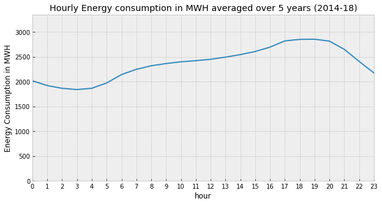

```python
#Plotting average hourly load profile observed over the entire period
SDGE_t_pv.groupby('hour')['SDGE'].mean().plot(figsize = (10,5))
_ = plt.ylabel('Energy Consumption in MWH')
_ = plt.ylim([0, max(SDGE_t_pv.groupby('hour')['SDGE'].mean()) + 500])
_ = plt.xticks(SDGE_t_pv['hour'].unique())
_ = plt.title('Hourly Energy consumption in MWH averaged over 5 years (2014-18)')
```

- From the above average hourly load profile graph we can observe how the load remains low over the night and then starts increasing as the region wakes up, and continues increasing during the office hours and peaks in the evening when everyone returns home and turns on the electrical appliances in their house.

**Plotting average monthly load profile over the entire period 2014-18**

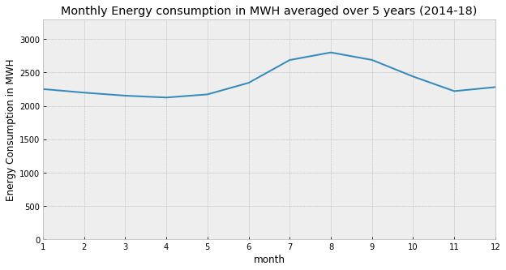

```python
##Plotting average monthly load profile
SDGE_t_pv.groupby('month')['SDGE'].mean().plot(figsize = (10,5))
_ = plt.ylabel('Energy Consumption in MWH')
_ = plt.ylim([0, max(SDGE_t_pv.groupby('month')['SDGE'].mean()) + 500])
_ = plt.xticks(SDGE_t_pv['month'].unique())
_ = plt.title('Monthly Energy consumption in MWH averaged over 5 years (2014-18)')
```

- As expected the monthly load profile peaks in the summer due to high cooling (air-conditioning) load caused by high temperatures.

**Plotting the trend of average monthly energy consumption observed for each month over the past 5 years**

```python
#Grouping the dataframe by month and year by applying groupby with an aggregate function of mean; converting the groupby
#object into a dataframe
df1 = SDGE_t_pv.groupby(['month','year'])['SDGE'].mean()
df1 = pd.DataFrame(df1)
```

```python
#Unstacking the above dataframe to get the data in a format we can plot
df1un = df1.unstack(level = 'month')
df1un.head()
```

| month year | SDGE 1 | SDGE 2 | SDGE 3 | SDGE 4 | SDGE 5 | SDGE 6 | SDGE 7 | SDGE 8 | SDGE 9 | SDGE 10 | SDGE 11 | SDGE 12 |
| --- | --- | --- | --- | --- | --- | --- | --- | --- | --- | --- | --- | --- |
| 2014 | 2289.122312 | 2287.229167 | 2237.892473 | 2256.341667 | 2435.094086 | 2416.908333 | 2756.000000 | 2803.717742 | 2939.491667 | 2521.405914 | 2231.704167 | 2308.564516 |
| 2015 | 2255.966398 | 2205.293155 | 2258.916667 | 2196.484722 | 2146.177419 | 2412.219444 | 2578.725806 | 2848.950269 | 2955.175000 | 2656.813172 | 2252.494444 | 2372.629032 |
| 2016 | 2298.233871 | 2208.837644 | 2122.209677 | 2120.487500 | 2105.094086 | 2417.443056 | 2649.155914 | 2723.741935 | 2507.890278 | 2347.349462 | 2244.836111 | 2262.787634 |
| 2017 | 2239.989221 | 2148.653488 | 2084.206675 | 2030.601724 | 2113.055748 | 2299.035590 | 2668.690458 | 2660.980782 | 2577.793395 | 2410.197772 | 2200.656761 | 2240.598360 |
| 2018 | 2175.139451 | 2141.691298 | 2061.274450 | 2022.019529 | 2061.729266 | 2179.901757 | 2781.200171 | 2962.965377 | 2458.121081 | 2262.201133 | 2173.380679 | 2221.340664 |

```python
#resetting the index to get year as a column
df1un.reset_index(inplace = True)
```

```python
#Melting the above dataframe to get the data in the required format to plot average monthly consumption for each month over the
#past 5 years
melt = pd.melt(df1un, id_vars='year', value_name='Avg. monthly energy consumption MWH')
melt.head()
```

|  | year | None | month | Avg. monthly energy consumption MWH |
| --- | --- | --- | --- | --- |
| 0 | 2014 | SDGE | 1 | 2289.122312 |
| 1 | 2015 | SDGE | 1 | 2255.966398 |
| 2 | 2016 | SDGE | 1 | 2298.233871 |
| 3 | 2017 | SDGE | 1 | 2239.989221 |
| 4 | 2018 | SDGE | 1 | 2175.139451 |

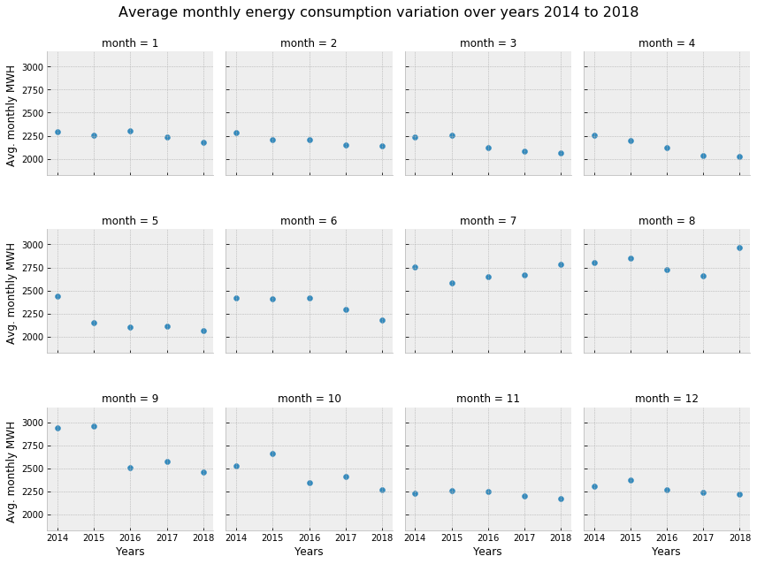

```python
#Plotting each month as a separate graph using Facetgrid
g = sns.FacetGrid(melt, col="month", margin_titles = True, col_wrap = 4)
g.map(plt.scatter, "year", "Avg. monthly energy consumption MWH");
g.set_axis_labels("Years", "Avg. monthly MWH ");
g.set(ylim=(melt['Avg. monthly energy consumption MWH'].min() - 200, melt['Avg. monthly energy consumption MWH'].max() + 200));
_ = plt.subplots_adjust(top=0.9)
_ = g.fig.suptitle('Average monthly energy consumption variation over years 2014 to 2018', fontsize = 16 )
```

- A weak trend can be observed in the data, but it is different for different months. For example, April, May, June, September and October months show a considerable downward trend, whereas other months not so much.

**Plotting a map of hourly vs weekdays energy consumption to see how the consumption varies across any particular week**

```python
#Using pivot table to create a dataframe having index as hours and columns as weekdays and each cell will contain the average
#energy consumption for that particular hour of the weekday

hour_weekday = SDGE_t_pv.pivot_table(values='SDGE', index='hour', columns = 'weekday', aggfunc = 'mean')
```

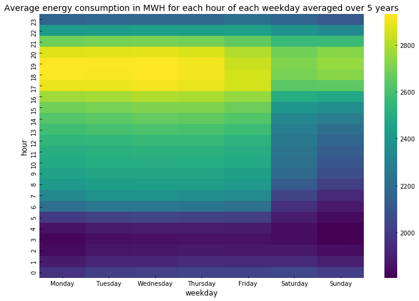

```python
#plotting a heatmap with a colorbar; the colorbar shows the energy consumption in MWH
_ = plt.figure(figsize=(12, 8))
ax = sns.heatmap(hour_weekday.sort_index(ascending = False), cmap='viridis')
#_ = plt.title('Average energy consumption in MWH for each hour of each weekday over the entire period')
_ = ax.set_title("Average energy consumption in MWH for each hour of each weekday averaged over 5 years", fontsize = 14)
```

- It can be seen that the average consumption from Monday to Friday is below 2000 in the night and it increases during the day and is at peak (>2800) during the evening time before sliding down again for the night. And on the weekends the same pattern can be observed but the overall consumption seems lower on weekends than weekdays as expected because most of the commercial buildings don't operate on weekends (also maybe because people go out on weekends and are not usually at home?)
- Also from all the above graphs it can be seen that the evening consumption is considerably higher than the rest of the day consumption. The reason for this, as pointed out earlier, is that people usually return home from work during evening hours (~4-9pm) and the consumption increases due to the turning on of electronic appliances like lights, TV, computers, air conditioning, etc.
- And due to the exact same reason, to keep the load on the electrical grid lower during this time, SDGE (and other utilities) try to discourage people from using more electricity during these hours. SDG&E began transitioning residential customers to Time-of-Use (TOU) pricing plans in early 2019; a TOU plan is one wherein the utiltiy applies different rates to the customers for different time slots during the day. And in fact, SDGE applies highest rate (peak rate) during 4pm to 9pm to its customers as compared to other hours during the day. From SDGE's website: "If customers can shift some of their energy use to lower-cost time periods outside 4 p.m. to 9 p.m., they can lower their electricity bills and make better use of cleaner, renewable energy sources, like wind and solar, when they are more available."

**Plotting a histogram to see the overall distribution of the energy consumption for SDGE territory**

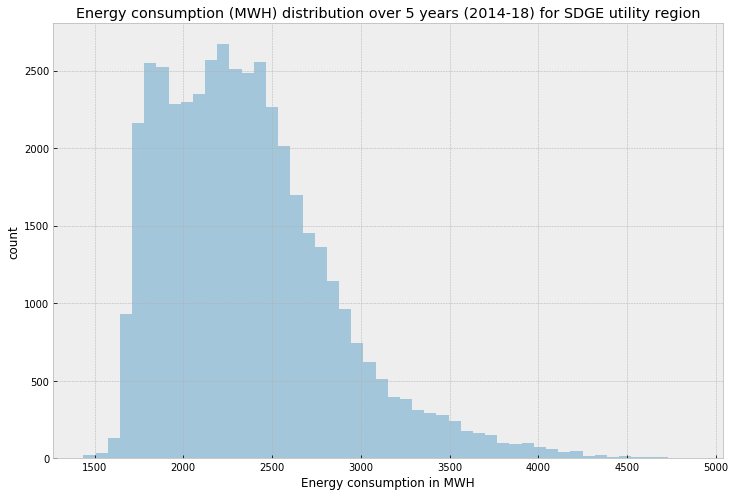

```python
_ = plt.figure(figsize = (12,8))
_ = sns.distplot(SDGE_t_pv['SDGE'], kde=False)
_ = plt.title('Energy consumption (MWH) distribution over 5 years (2014-18) for SDGE utility region')
_ = plt.xlabel('Energy consumption in MWH')
_ = plt.ylabel('count')
```

- It can be seen that most of the days (for 2014-18) have energy consumption between ~1700 to ~2500 MWH and the maximum demand is around ~4800MWH.

**Plotting the distribution again but this time using box plot and dividing the columns of the plot by weekdays and adding a hue for working and non-working days**

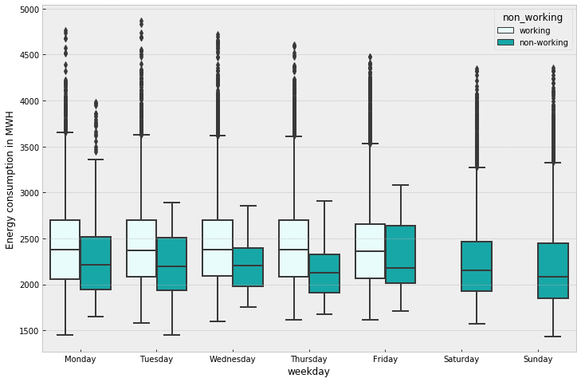

```python
_ = plt.figure(figsize = (12,8))
_ = sns.boxplot(x = 'weekday', y = 'SDGE', data = SDGE_t_pv, color='c', hue='non_working')
_ = plt.ylabel('Energy consumption in MWH')
```

- It can be seen that the median energy consumption on working days remains fairly same from Monday to Friday and drops on the weekend as seen before in the heatmap. Also, if a particular day is a holiday or non-working day (indicated in dark green) the energy consumption is much lower than if the same day was a working day as expected.

**Visualizing the distribution of energy values for different years**

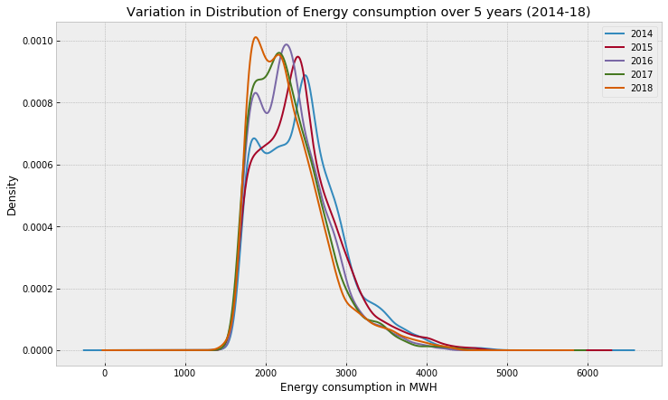

```python
for year in SDGE_t_pv['year'].unique():
    SDGE_t_pv[SDGE_t_pv['year'] == year]['SDGE'].plot(kind='density', figsize = (12,7), legend = True, label = year)
_ = plt.xlabel('Energy consumption in MWH')
_ = plt.title('Variation in Distribution of Energy consumption over 5 years (2014-18)')
```

- For all the years the distirubtion is kind of bi-modal and the mode values for energy consumption consistently shifts towards left (towards lower energy load) each year from 2014 to 2018.
- This shift can be assumed to be caused by increasing renewable energy installations at customer sites (called as behind the meter) causing the customers to consume lower energy from the SDGE grid.

**Plotting the above distribution for summer and winter seasons separately**

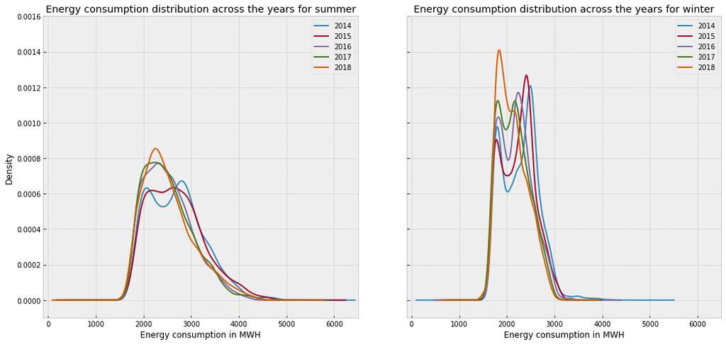

```python
season = ['summer', 'winter']
#color_names = ["tab:blue", "tab:orange", "tab:green", "tab:red" , "tab:purple"]
for i, season in enumerate(season):

    ax = plt.subplot(121+i)
    for j, year in enumerate(SDGE_t_pv['year'].unique()):
        _ = SDGE_t_pv[(SDGE_t_pv['year'] == year) & (SDGE_t_pv['season'] == season)]['SDGE'].\
                                plot(kind='density', figsize=(15,7), legend=True, label= year, sharey=True)#, \
                                #c = color_names[j])
    _ = plt.title('Energy consumption distribution across the years for '+season)
    _ = plt.ylim(-0.0001, 0.0016)
    _ = plt.xlim(-100, 6500)
    _ = plt.xlabel('Energy consumption in MWH')

_ = plt.tight_layout()
```

- The energy consumption for summer months is more wide spread and is more right skewed towards higher values as compared to winter months for reasons discussed previously.
- The energy consumption is bimodal for winter months for all the 5 years whereas the energy consumption is bimodal for summer months for years 2014 and 2015 and starts getting unimodal for years 2016 through 2018.
- Also, the trend of maximum energy consumption shifting towards lower values is more dominant for winter months as compared to the summer months.

**Plotting maximum monthly energy consumption (peak demand of a month) over the years 2014-18**

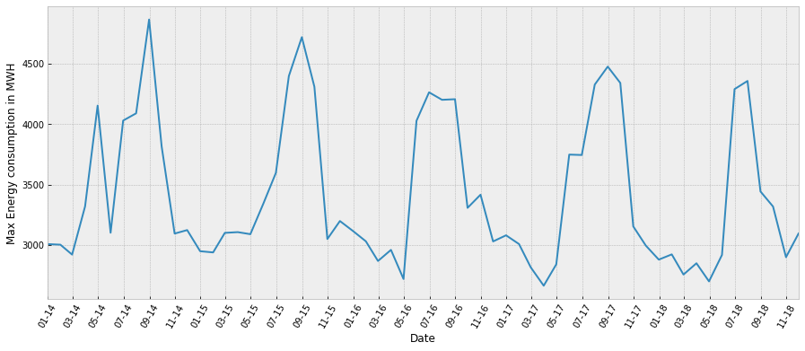

```python
# Resampling the energy data monthly and calculating the max energy consumption for each month
monthly_en = SDGE_t_pv.resample('M', label = 'left')['SDGE'].max()
_ = plt.figure(figsize = (15,6))
#plotting the max monthly energy consumption
_ = plt.plot(monthly_en)
# ensuring the limits on x axis to be between the dataframe's datetime limits
_ = plt.xlim(monthly_en.index.min(), monthly_en.index.max())
# Using matplotlib MonthLocator to be used in the xticks to mark individual months
locator = mdates.MonthLocator(bymonthday = 1, interval = 2)  # every 2 months
fmt = mdates.DateFormatter('%m-%y')  # xticks to be displayed as 01-14 (i.e. Jan'14) and so on
X = plt.gca().xaxis
# Setting the locator
X.set_major_locator(locator)
# Specify formatter
X.set_major_formatter(fmt)
_ = plt.xticks(rotation = 60)
_ = plt.ylabel('Max Energy consumption in MWH')
_ = plt.xlabel('Date')
#_ = plt.figure(figsize=(15,6))
#_ = SDGE_t_pv['SDGE'].rolling(24*30).max().plot()
```

- The max monthly peak demand or energy consumption seems to have slightly decreased over the years.

**Plotting distribution of energy consumption for every hour over the years**

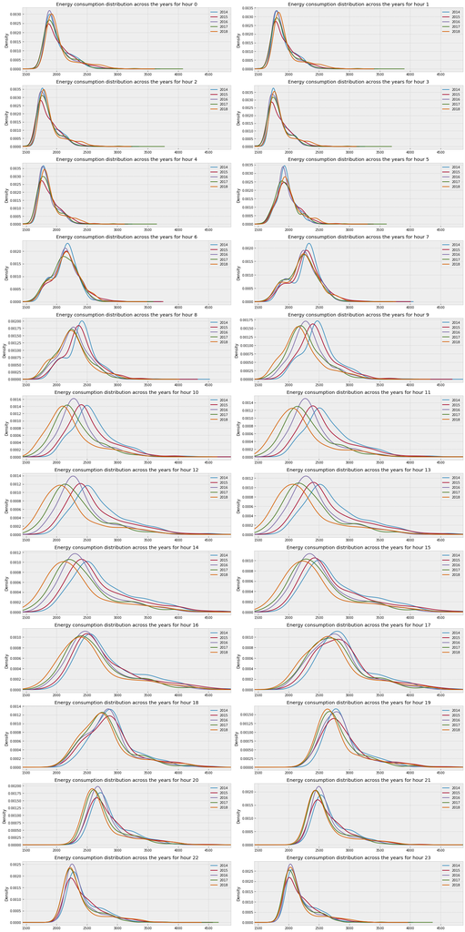

```python
f = plt.figure(figsize = (20,40))
peak_hours = np.arange(0,24)
for i, hour in enumerate(peak_hours):
    ax = f.add_subplot(12,2,i+1)
    for j, year in enumerate(SDGE_t_pv['year'].unique()):
        SDGE_t_pv[(SDGE_t_pv['year'] == year) & (SDGE_t_pv['hour'] == hour)]['SDGE'].\
                                plot(kind='density',  sharey=False, legend=True, label= year)# ,\
                                #c = color_names[j])
    plt.title('Energy consumption distribution across the years for hour '+str(hour))
    plt.xlim(np.min(SDGE_t_pv.SDGE.values), np.max(SDGE_t_pv.SDGE.values))
plt.tight_layout()
#plt.subplots_adjust(left=0.125, bottom=0.1, right=0.9, top=0.9, wspace=0.3, hspace=1)
```

- We can see from the above graphs that the energy consumption distribution for each hour has shifted towards lower energy consumption values from 2014 to 2018, and this effect is more dominant during the daylight hours of 8am to 5pm.
- One of the reasons for this shift during daylight hours can be the addition of more renewables like solar and wind behind the customer meters. We will see later that the solar installations in the SDGE have increased cosiderably over the last 5 years.

## 3.2 Exploring energy and weather data together

**Plotting the energy and weather data together to check for any potential correlation**

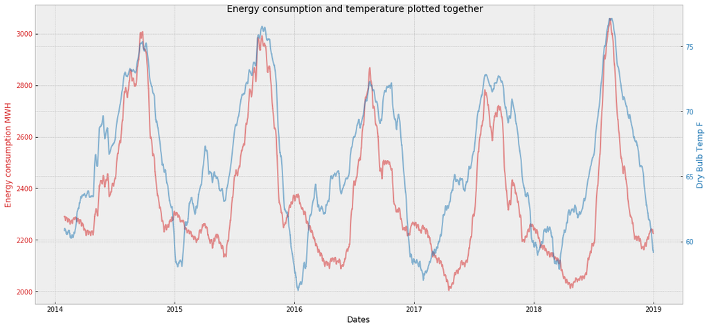

```python
# Plotting the energy and weather data on the same graph as line plots
fig, ax1 = plt.subplots(figsize=(15,7))
rolling_num = 24*30 # smoothing the data a bit by taking the mean of last 'rolling_num' values
#i.e. plotting the 30 day average energy consumption and temperature values
color = 'tab:red'
ax1.set_xlabel('Dates')
ax1.set_ylabel('Energy consumption MWH', color = color)
ax1.plot(SDGE_t_pv['SDGE'].rolling(rolling_num).mean(), color = color, alpha = 0.5)
ax1.tick_params(axis='y', labelcolor = color)

ax2 = ax1.twinx()  # instantiate a second axes that shares the same x-axis

color = 'tab:blue'
ax2.set_ylabel('Dry Bulb Temp F', color = color)  # we already handled the x-label with ax1
ax2.plot(SDGE_t_pv['HourlyDryBulbTemperature'].rolling(rolling_num).mean(), color = color, alpha = 0.5)
ax2.tick_params(axis='y', labelcolor = color)

fig.suptitle('Energy consumption and temperature plotted together', fontsize = 14)
fig.tight_layout()
plt.show()
```

- As suspected before, we can see that the energy consumption and temperature do kind of follow each other and seem to have some level of correlation betweem them.
- More importantly we can see that the highest energy consumption values occur at highest temperatures. This, as mentioned before, is the reason of higher air conditioning loads at higher temperatures.

**Plotting a linear regression plot between the energy consumption and temperature**

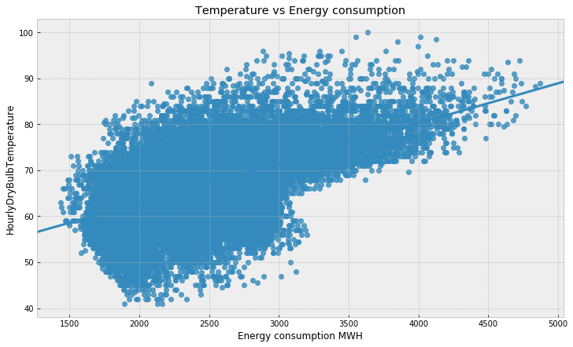

```python
_ = plt.figure(figsize=(12,7))
seasons = ['summer', 'winter' ] # edit this accordingly if you want to plot the regplot for any one particular season
hours = np.arange(0,23) # edit this accordingly if you want to plot the regplot for a particular range of hours
_ = sns.regplot(x= 'SDGE', y= 'HourlyDryBulbTemperature' , data= \
            SDGE_t_pv[(SDGE_t_pv['season'].isin(seasons)) & (SDGE_t_pv['hour'].isin(hours))])
_ = plt.xlabel('Energy consumption MWH')
_ = plt.title('Temperature vs Energy consumption')
```

- There seems to be a pretty decent correlation between the energy consumption and the temperature, as suspected before, which is expected because high heat calls out for more air conditioning loads. This correlations gets better if we plot only summer months.

**We can also see the correlations using the scipy.stats.pearsonr function. The scipy.stats.pearsonr function returns the pearsonr coefficient and the pvalue of observing such coefficient if we were to assume that there was no correlation between the x and y data sets. Let's select a signifance level of 5%, and so if the pvalue is <5%, we will assume that the correlation coefficienct returned is significant.**

```python
# Let's calculate the pearsonr coefficient between the energy and temperature
scipy.stats.pearsonr(SDGE_t_pv['SDGE'], SDGE_t_pv['HourlyDryBulbTemperature'])
```

```
(0.5746255942794394, 0.0)
```

- So the correlation between the energy consumption and the temperature is positive and also since the pvalue is almost 0, we can say that the correlation is not a result of random chance.
- Calculating the same pearson coefficient for winter and summer seasons to check the assumption that the summer season will have a higher correlation due to higher cooling loads calling out for higher energy consumption.

```python
for season in SDGE_t_pv['season'].unique():
    corrcoef, pvalue = scipy.stats.pearsonr(SDGE_t_pv[SDGE_t_pv['season'] == season]['SDGE'], \
                                            SDGE_t_pv[SDGE_t_pv['season'] == season]['HourlyDryBulbTemperature'])
    print('pearson correlation coefficient and pvalue for '+season, corrcoef, pvalue)
```

```
pearson correlation coefficient and pvalue for winter 0.3205671197053533 0.0
pearson correlation coefficient and pvalue for summer 0.650039994883929 0.0
```

- As expected the correlation coefficient for summer is higher than that for the winter (almost twice).

## 3.3. Exploring energy and PV installations data together

As observed in section 3.1, the energy consumption for daylight hours seems to have decreased from 2014 to 2018. Now, this can be due to sricter energy efficiency measures being mandated, or increase in incentives for different categories of ratepayers (residential, commercial, agriculture, etc.) to install self-generation resources like solar, wind, etc. and/or energy storage in their premises to avoid the higher energy demand. It was observed that the energy consumption decrease over the years is more dominant over the daylight hours, so we can test the theory that maybe solar capacity installed in the utility region has increased over the years, which it has as we will see below.

**Plotting the PV installations data over the years**

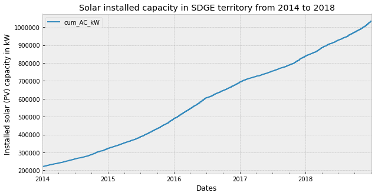

```python
_ = SDGE_t_pv.cum_AC_kW.plot(figsize=(10,5))
_ = plt.legend()
_ = plt.title('Solar installed capacity in SDGE territory from 2014 to 2018')
_ = plt.ylabel('Installed solar (PV) capacity in kW')
```

**Let's calculate the pearson correlation coefficient between the energy consumption and installed PV capacity (restricting the hours to sunlight hours, roughy 10 am to 3 pm because San Diego usually gets 5 hours of peak sunlight on an average over the entire year- ref: https://www.wholesalesolar.com/solar-information/sun-hours-us-map).**

```python
daylight_hours = np.arange(10, 16) # edit this accordingly to select any range of hours

for season in SDGE_t_pv['season'].unique():
    corrcoef, pvalue = scipy.stats.pearsonr(SDGE_t_pv[(SDGE_t_pv['season'] == season) & \
                                                        (SDGE_t_pv['hour'].isin(daylight_hours))]\
                                            ['SDGE'], \
                                            SDGE_t_pv[(SDGE_t_pv['season'] == season) & \
                                                        (SDGE_t_pv['hour'].isin(daylight_hours))]\
                                            ['cum_AC_kW'])
    print('Energy consumption vs PV installed capacity: pearson correlation coefficient and pvalue for '\
          +season, corrcoef, round(pvalue, 4))
```

```
Energy consumption vs PV installed capacity: pearson correlation coefficient and pvalue for winter -0.5154837639331172 0.0
Energy consumption vs PV installed capacity: pearson correlation coefficient and pvalue for summer -0.33798371877307193 0.0
```

- The correlation seems to be significant for both the seasons and is much stronger for winter months. It’s a bit counterintuitive, but colder temperatures are actually better for solar panels than warm temperatures are. This relationship holds true across most types of solar panels – and has nothing to do with the installation process itself. Studies conducted in laboratories all over the world clearly show that increases in temperature have an inverse effect on the total solar output of the panels tested. In other words, the hotter it gets, the less efficient your solar PV system becomes.
- Thus, all things being equal, your monthly utility bill savings will be less during June, July, August than they will be in December, February, and January. Ref: https://www.sunlineenergy.com/solar-pv-power-output-san-diegos-winter-months/

# 4. Future work

- Build a simple model to predict the energy consumption based on just the date and time features. Treat this as the baseline model.
- Add in more features like the temperature and PV installed capacity data and check if the performance improves compared to the baseline.